# Non-probability-based Surveys in Practice

Analysis solution

Bernhard Clemm von Hohenberg [^1]

Summer Institute in Computational Social Science 2023

# Load packages and data

If you are using your own survey data, you will need to do some pre-processing as described in `preprocessing-template.Rmd`.

```r
# read in pre-processed simulated data file
prolific <- read.csv("data-simulated/survey-simulated-clean.csv")

# read in census data
census <- read.csv("data-census/census-2021-cleaned.csv", sep = ";")
## as our target population are adults, we drop <18 year olds
census <- census %>%
  filter(age_group != "<18")

# load Eurobarometer benchmarks
eb_means <- read.csv("data-eurobarometer/eb99_2023_means.csv", sep = ";")
eb_means <- eb_means %>%
  select(varname_sicss, proportion) %>%
  rename("estimate_eb" = proportion)
```

# Approach 1: Simple means

First, we’ll just take the mean of the whole sample for each question. This approach doesn’t use any post-stratification.

## 1.1 Calculate means

|  | varname_sicss | mean |
| --- | --- | --- |
| 1 | lifesat.1 | 0.37803321 |
| 2 | lifesat.2 | 0.49169860 |
| 3 | lifesat.3 | 0.08556833 |
| 4 | lifesat.4 | 0.04469987 |
| 5 | econnow.1 | 0.03703704 |
| 6 | econnow.2 | 0.18773946 |

## 1.2) Plot estimated means against benchmarks

As you will be making this type of plot each time you generate a new set of estimates, we wrap the plotting in a function.

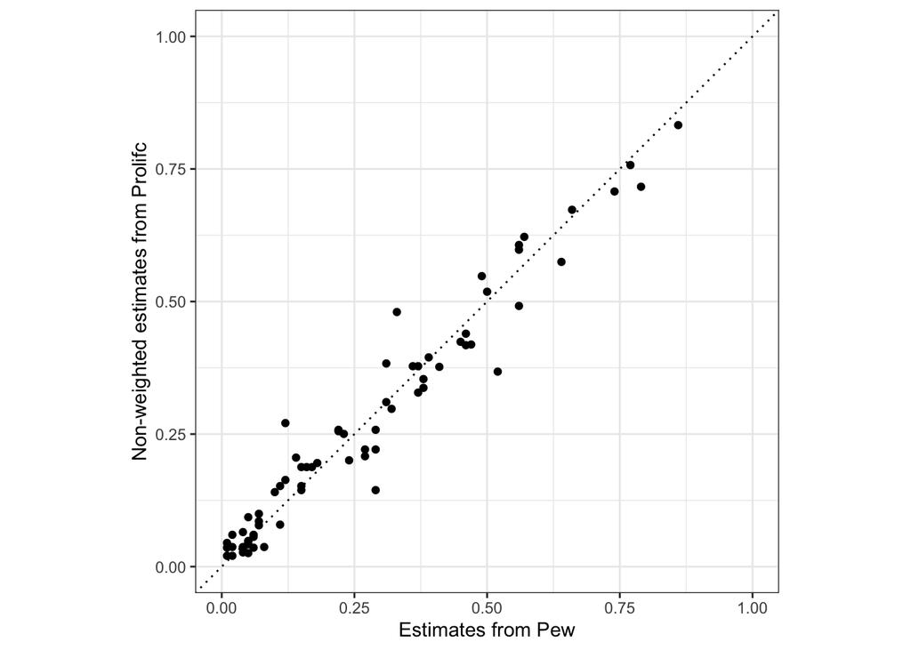

## 1.3) Plot distribution of estimation-benchmark differences

Again, as you will be making this type of plot each time you generate a new set of estimates, we wrap the plotting in a function.

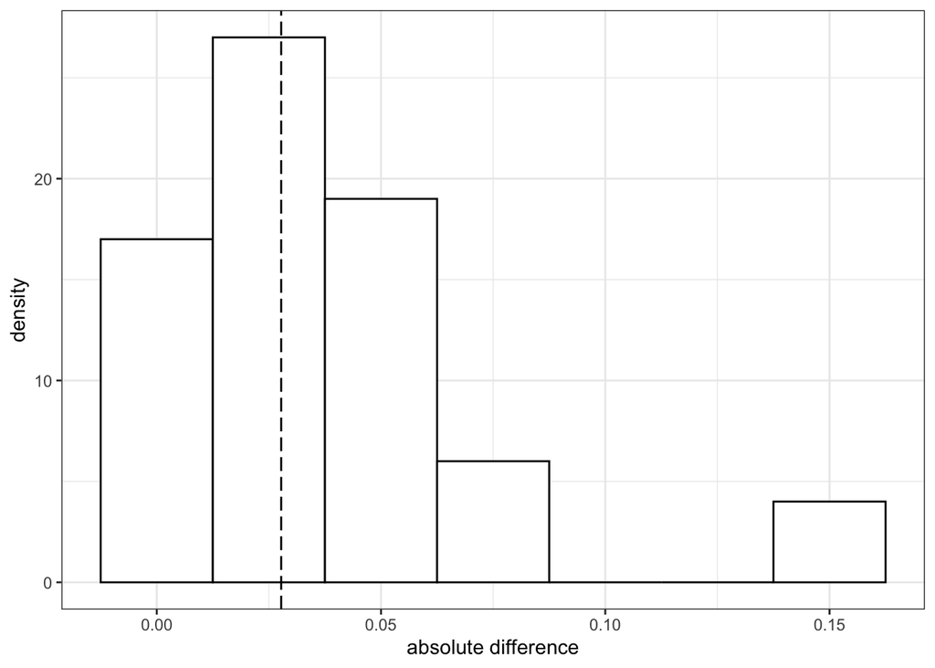

# Approach 2: Means with post-stratification (8 groups)

## 2.1) Calculate group means, group weights, and weighted means

To start, group by sex and age group only. This should give you 8 groups (2 sexes by 4 age groups). Group weights can be calculated as $\frac{N_{h}}{N}$. They should sum to 1. You will need to calculate these group weights for the other approaches as well.

| varname_sicss | cell_estimate |
| --- | --- |
| demsat.1 | 0.09234754 |
| demsat.2 | 0.38322764 |
| demsat.3 | 0.33972965 |
| demsat.4 | 0.16440623 |
| demsat.5 | 0.02028895 |
| discuss_eu.1 | 0.16078609 |

## 2.2) Plot estimated means against benchmarks

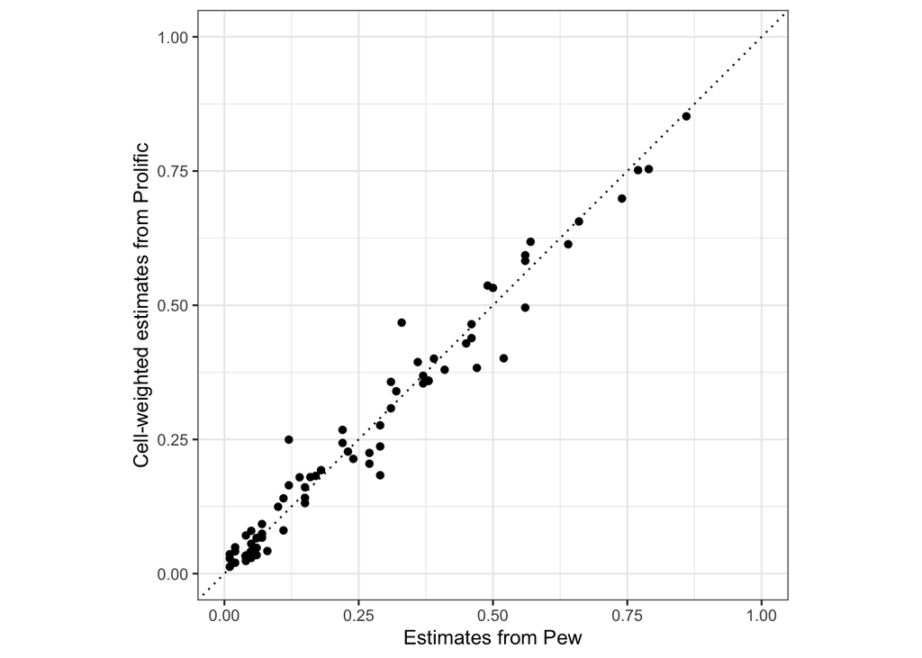

## 2.3) Plot distribution of estimation-benchmark differences

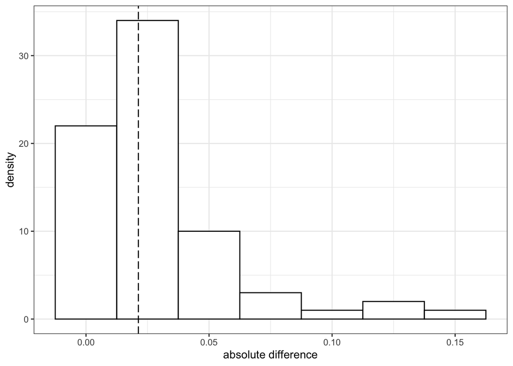